# Stats 769 Lab 6

Chase Robertson

2022-09-20

# The Data Set

```r
library(MASS)
library(e1071)
library(class)
library(parallel)

set.seed(123)

bank = read.csv("bank-subset.csv", strings=TRUE)
X = model.matrix(y ~ ., data=bank)[,-1]        # design matrix, without intercept
i = 1:1000
train = data.frame(X[i,], y=bank$y[i])         # training set
test = data.frame(X[-i,], y=bank$y[-i])        # test set

summary(bank)
```

```
##       age                 job           marital         education    default
##  Min.   :19.00   blue-collar:1035   divorced: 611   primary  : 733   no :4916
##  1st Qu.:33.00   management :1033   married :2983   secondary:2559   yes:  84
##  Median :39.00   technician : 838   single  :1406   tertiary :1467
##  Mean   :41.01   admin.     : 600                   unknown  : 241
##  3rd Qu.:48.00   services   : 450
##  Max.   :89.00   retired    : 258
##                  (Other)    : 786
##     balance         housing     loan           contact          day
##  Min.   :-2827.00   no :2267   no :4210   cellular :3224   Min.   : 1.00
##  1st Qu.:   83.75   yes:2733   yes: 790   telephone: 318   1st Qu.: 8.00
##  Median :  465.00                         unknown  :1458   Median :16.00
##  Mean   : 1431.58                                          Mean   :15.77
##  3rd Qu.: 1523.50                                          3rd Qu.:21.00
##  Max.   :52587.00                                          Max.   :31.00
##
##      month         duration         campaign          pdays
##  may    :1502   Min.   :   0.0   Min.   : 1.000   Min.   : -1.00
##  jul    : 757   1st Qu.: 102.0   1st Qu.: 1.000   1st Qu.: -1.00
##  aug    : 667   Median : 178.5   Median : 2.000   Median : -1.00
##  jun    : 624   Mean   : 255.6   Mean   : 2.726   Mean   : 41.06
##  nov    : 438   3rd Qu.: 315.2   3rd Qu.: 3.000   3rd Qu.: -1.00
##  apr    : 336   Max.   :3422.0   Max.   :36.000   Max.   :871.00
##  (Other): 676
##     previous          poutcome      y
##  Min.   : 0.0000   failure: 551   no :4459
##  1st Qu.: 0.0000   other  : 190   yes: 541
##  Median : 0.0000   success: 161
##  Mean   : 0.5934   unknown:4098
##  3rd Qu.: 0.0000
##  Max.   :58.0000
##
```

# Introduction

1. In your own words, describe briefly the data and the practical problem that is associated with the data.

The data is quite imbalanced, as only 10% of the outcomes in the variable y are positive. There are also many missing values, as is especially clear in the contact and poutcome variables. These missing values are treated as separate classes in the input, which may yield suboptimal results as compared with imputed values.

# Basic Classification Methods

2. Use the linear discrimant analysis to predict the class labels. Produce the confusion matrix and compute the misclassification rate, for both the training and test sets.

```r
confusion_and_rate <- function(true, predicted, display=T) {
    if (display) print(table(true, predicted))
    if (display) cat("Misclassification rate:", mean(true != predicted), fill=T)
    else mean(true != predicted)
}

lda_fit <- lda(y ~ ., train)
lda_train_pred <- predict(lda_fit, train)
confusion_and_rate(train$y, lda_train_pred$class)
```

```
##      predicted
## true   no yes
##   no  863  29
##   yes  63  45
## Misclassification rate: 0.092
```

```r
lda_test_pred <- predict(lda_fit, test)
confusion_and_rate(test$y, lda_test_pred$class)
```

```
##      predicted
## true    no  yes
##   no  3430  137
##   yes  258  175
## Misclassification rate: 0.09875
```

Test prediction is marginally less accurate than training set prediction, which meets expectations for a model that is well fit. However, there are more false negatives than false positives or true positives, which may not be ideal depending on the purpose of the model.

3. Use the Naive Bayes method to predict the class labels. Produce the confusion matrix and compute the misclassification rate, for both the training and test sets.

```r
nb <- naiveBayes(y ~ ., train)
nb_train_pred <- predict(nb, train)
confusion_and_rate(train$y, nb_train_pred)
```

```
##      predicted
## true   no yes
##   no  721 171
##   yes  34  74
## Misclassification rate: 0.205
```

```r
nb_test_pred <- predict(nb, test)
confusion_and_rate(test$y, nb_test_pred)
```

```
##      predicted
## true    no  yes
##   no  2887  680
##   yes  173  260
## Misclassification rate: 0.21325
```

4. Use the K-nearest-neighbour (KNN) method to predict the class labels, with K=1,5, respectively. Produce the confusion matrix and compute the misclassification rates, for both the training and test sets.

```r
for (k in c(1, 5)) {
    cat(paste("k =", k), "Train", fill=T)
    knn_train_pred <- knn(train[,-43], train[,-43], cl=train$y, k=k)
    confusion_and_rate(train$y, knn_train_pred)
    cat(paste("k =", k), "Test", fill=T)
    knn_test_pred <- knn(train[,-43], test[,-43], cl=train$y, k=k)
    confusion_and_rate(test$y, knn_test_pred)
}
```

```
## k = 1 Train
##      predicted
## true   no yes
##   no  892   0
##   yes   0 108
## Misclassification rate: 0
## k = 1 Test
##      predicted
## true    no  yes
##   no  3290  277
##   yes  299  134
## Misclassification rate: 0.144
## k = 5 Train
##      predicted
## true   no yes
##   no  882  10
##   yes  87  21
## Misclassification rate: 0.097
## k = 5 Test
##      predicted
## true    no  yes
##   no  3485   82
##   yes  364   69
## Misclassification rate: 0.1115
```

With K=1, the label of the nearest neighbor is assigned as prediction, so training accuracy is naturally perfect. On the test set there are plenty of positive predictions, mostly false, and plenty of false negatives due to noise. While increasing K to 5 causes more neighbors’ labels to be included in prediction, and better overall accuracy, there are fewer positive predictions due to the imbalance of the class distribution.

5. Use the K-nearest-neighbour (KNN) method to predict the class labels, with K=1,2,…,30 respectively. Compute the misclassification rates, for both the training and test sets. Show the two curves for the misclassification rate versus K in one graph.

```r
K = 30
train_rates = 1:K
test_rates = 1:K
for (k in 1:K) {
    knn_train_pred <- knn(train[,-43], train[,-43], cl=train$y, k=k)
    train_rates[k] = confusion_and_rate(train$y, knn_train_pred, display=F)
    knn_test_pred <- knn(train[,-43], test[,-43], cl=train$y, k=k)
    test_rates[k] = confusion_and_rate(test$y, knn_test_pred, display=F)
}
```

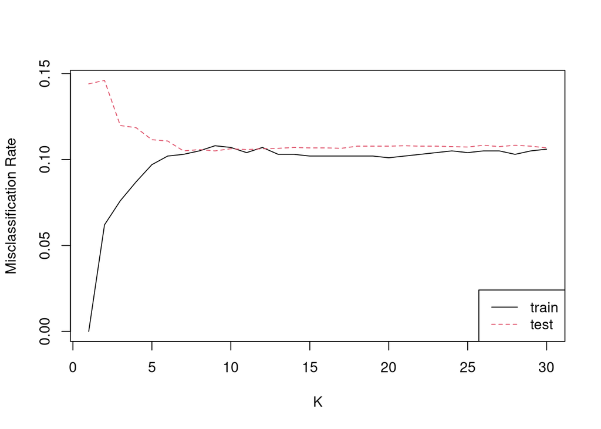

```r
rates <- data.frame(train=train_rates, test=test_rates)
matplot(rates, type="l", xlab="K", ylab="Misclassification Rate")
legend("bottomright", names(rates), col=1:2, lty=1:2)
```

With low K, training error is very low because the nearest neighbor is always the correct prediction. This is not the case in the test set, so error is high because of noise. As K increases, the decision boundary becomes softer and more general, so training and test error equalise. They seem to meet at K=7.

# Data resampling

In the following, let us consider how to use data resampling methods to find an appropriate value for a tuning parameter, here the value of K in the KNN classificaiton method.

## Cross-validation

6. Use 10-fold cross-validation, with 20 repetitions, to find an appropriate value for K in KNN from the training data only. Explain why you have used the technique of same subsamples.

```r
R <- 20
CV <- 10
errors <- matrix(nrow=R*CV, ncol=K)
for (r in 1:R) {
    # shuffle training set in each repetition
    j <- sample(1:nrow(train))
    for (i in 1:CV) {
        # choose 1/10th of training set for validation
        trn <- train[j %% CV != i-1, ]
        vld <- train[j %% CV == i-1, ]

        for (k in 1:K) {
            # fit a model with every possible K on this subsample
            pred <- knn(trn[,-43], vld[, -43], cl=trn[, 43], k=k)
            errors[CV*(r-1)+i, k] = mean(vld[,43] != pred)
        }
    }
}
```

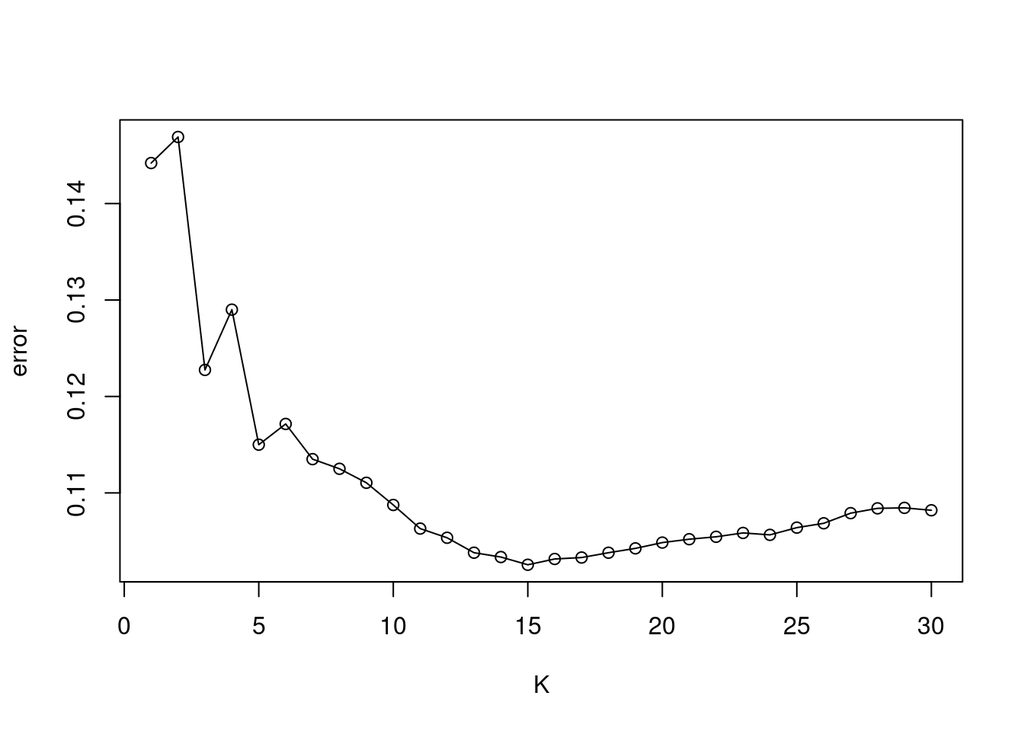

```r
cv_knn <- colMeans(errors)
plot(1:K, cv_knn, type="o", xlab="K", ylab="error")
```

```r
which.min(cv_knn)
```

```
## [1] 15
```

The same subsamples technique reduced the variance of resulting Prediction Error estimates, since the random variation between validation sets was shared among each k-nn method. Sharing subsamples likely also reduced the computation time, since fewer random subsamples were necessary.

## Jackknifing and Parallel Computing

7. Use the Jackknifing technique (with a 90% for training and 10% for testing) to find an appropriate value for K in KNN from the training data only. Use R = 200 as the number of repetitions.

```r
R <- 200
errors <- matrix(nrow=R, ncol=K)
for (r in 1:R) {
    ind <- sample(1:nrow(train))
    trn <- train[ind %% 10 != 0, ]
    vld <- train[ind %% 10 == 0, ]
    for (k in 1:K) {
        pred <- knn(trn[,-43], vld[, -43], cl=trn[, 43], k=k)
        errors[r, k] = mean(vld[,43] != pred)
    }
}
```

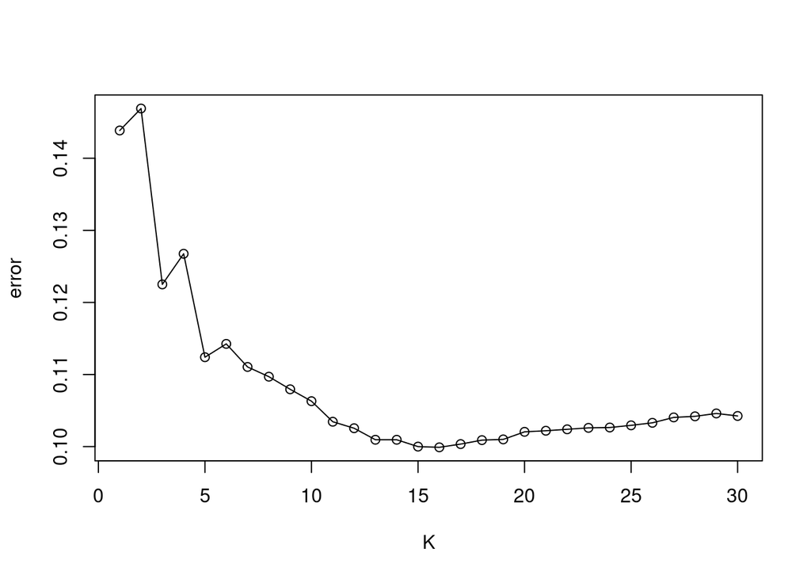

```r
jk_knn <- colMeans(errors)
plot(jk_knn, xlab='K', ylab='error', type="o")
```

```r
which.min(jk_knn)
```

```
## [1] 16
```

The main difference between this jackknife method and repeated cross-validation is the total independence of each train/test split. CV splits the set into folds and repeats the training with each block reserved for validation, whereas here each training set is independently sampled from the whole training set.

8. Rewrite/reorganise your code so that each repetition can be carried out independently. Perform the Jackknifing selection of the K-value from the training set using parallel computing, with function mclapply().

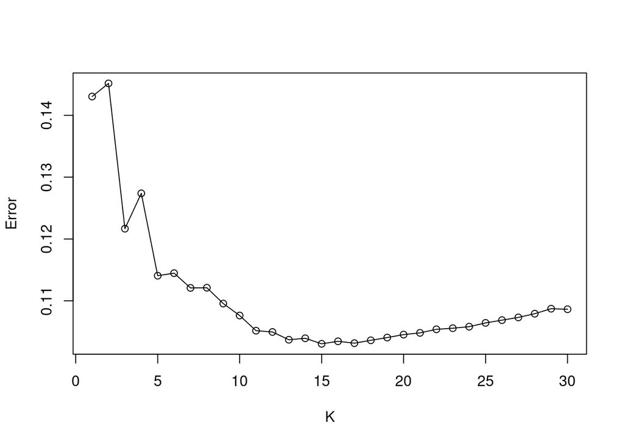

```r
# option to parallelise by K or by repetitions
# choose to parallelise repetitions to reduce variance of means and enable ncores > nK
# parallelisation argument is random seed to ensure independence of results
jackknife <- function(data, proportion=0.1, K=30, R=10, seed=123) {
    set.seed(seed)
    pe <- matrix(nrow=R, ncol=K)
    colnames(pe) <- 1:K
    for (r in 1:R) {
        ind <- sample(1:nrow(data))
        vld_ind <- ind[1:nrow(data)*proportion]
        trn <- data[ind[-vld_ind], ]
        vld <- data[ind[vld_ind], ]
        for (k in 1:K) {
            pred <- knn(trn[,-43], vld[,-43], cl=trn[,43], k=k)
            pe[r, k] = mean(vld[,43] != pred)
        }
    }
    colMeans(pe)
}

l <- mclapply(X=list(seed=(1:K)*K), FUN=jackknife, data=train, proportion=0.1, K=K, R=R)
kerr <- colMeans(matrix(unlist(l), ncol=K))
plot(kerr, xlab='K', ylab='Error', type='o')
```

I chose to parallelise the repetitions of jackknife, so the same-subsamples technique can still be used. This requires that a different random seed be passed to each individual job to correctly generate independent results.

Compare the timings, when 1, 5, 10 or 20 cores are used (so you have to do this on a VM).

```r
total_reps <- R
cores <- c(1, 5, 10, 20)
for (c in cores) {
    seed <- 123 * c^2
    reps_per_core <- total_reps / c
    time <- system.time(
        colMeans(matrix(unlist(mclapply(
            list(seed=seed), FUN=jackknife, data=train, proportion=0.1,
            K=K, R=reps_per_core, mc.cores=c)), ncol=K))
        )
    cat("With", c, "core(s):", fill=T)
    print(time)
}
```

```
## With 1 core(s):
##    user  system elapsed
## 218.064   0.000 218.113
## With 5 core(s):
##    user  system elapsed
##  42.895   0.000  42.905
## With 10 core(s):
##    user  system elapsed
##  23.953   0.000  23.958
## With 20 core(s):
##    user  system elapsed
##  10.608   0.000  10.610
```

9. For results to be reproducible, it is better to use random seeds. Investigate and demonstrate how this can be achieved when mclapply() is used.

```r
# each parallel job should be fed a distinct, but deterministic seed
# my jackknife function already handles this

# only addition is to select seeds and pass to each job
seeds <- seq(123, by=769, length.out=max(cores))
for (i in seq_along(cores)) {
    c = cores[i]
    c_seeds = seeds[1:c]
    reps_per_core <- total_reps / c
    time <- system.time(
        colMeans(matrix(unlist(mclapply(
            list(seed=c_seeds), FUN=jackknife, data=train, proportion=0.1,
            K=K, R=reps_per_core, mc.cores=c)), ncol=K))
        )
    cat("With", c, "core(s):", fill=T)
    print(time)
    cat("Seed(s) utilised by each core:", c_seeds, fill=T)
}
```

```
## With 1 core(s):
##    user  system elapsed
## 217.594   0.000 217.646
## Seed(s) utilised by each core: 123
## With 5 core(s):
##    user  system elapsed
##  43.695   0.000  43.705
## Seed(s) utilised by each core: 123 892 1661 2430 3199
## With 10 core(s):
##    user  system elapsed
##  22.444   0.000  22.447
## Seed(s) utilised by each core: 123 892 1661 2430 3199 3968 4737 5506 6275 7044
## With 20 core(s):
##    user  system elapsed
##  10.846   0.000  10.848
## Seed(s) utilised by each core: 123 892 1661 2430 3199 3968 4737 5506 6275 7044
## 7813 8582 9351 10120 10889 11658 12427 13196 13965 14734
```

As mentioned previously, all that is needed to guarantee independence of repetitions across cores is to feed different random seeds to each parallel job. I have experimented with a few methods of doing so, and found that pre-generating seeds as a range of values most simple, though am not sure of the level of independence achieved with this method.

# Summary

In this report, imbalanced data is predicted using various classifiers, with varying levels of success. A special note is made of tradeoffs between true/false positive/negative rates under the classifier methods. Cross-validation and jackknife data resampling methods are also explored, with the computation time of parallelised versions compared to sequential methods. With independent repetitions of the process, parallelisation is quite simple to implement, with significant gains in clock-time computation.